# “Keep it maximal”: Consequences of omitting (warranted) random slopes

Author

Jacob Goldstein-Greenwood

Published

2025-04-17

Barr et al., 2013, *Journal of Memory and Language*, “Random effects structure for confirmatory hypothesis testing: Keep it maximal.” DOI: [10.1016/j.jml.2012.11.001](https://pmc.ncbi.nlm.nih.gov/articles/PMC3881361/pdf/nihms533954.pdf).

> “Overall, our analysis suggests that, when specifying random effects for hypothesis testing with LMEMs, researchers have been far too concerned about *overfitting the data*, and not concerned enough about *underfitting the design*. In fact, it turns out overfitting the data with a maximal model has only minimal consequences for Type I error and power….”

I simulated data in which the population-level fixed effect of a within-cluster binary predictor, `x`, was zero but in which there were non-zero random intercepts and random slopes (distributed normally around zero). I.e., there was no overall average treatment effect, but there were within-cluster differences as `x` varied.

I then fit the following mixed-effects models:

$$Random\ intercepts: y_{ij} = \gamma_{00} + \beta_1x_{ij} + \mu_{0j} + e_{ij}$$
$$Random\ slopes: y_{ij} = \gamma_{00} + \beta_1x_{ij} + \mu_{0j} + \mu_{1j}x_{ij} + e_{ij}$$

I repeated the data-simulation and model fitting process 1000 times, recording on each iteration the estimated standard error of the fixed effect and the (Satterthwaite-df-based) *p* value from each model.

```r
library(lme4)
library(ggplot2)

set.seed(999)

sim <- function(n = 500, n_clust = 50,
                ranint_sd = 1, ranslope_sd = .5,
                e_sd = .5, b1 = 0) {
  clust <- rep(1:n_clust, each = n/n_clust)
  ranint <- rnorm(n_clust, mean = 0, sd = ranint_sd)[clust]
  ranslope <- rnorm(n_clust, mean = 0, sd = ranslope_sd)[clust]
  e <- rnorm(n, mean = 0, sd = e_sd)
  x <- rbinom(n, size = 1, prob = .5)
  y <- 0 + b1*x + ranint + ranslope*x + e
  RI <- summary(lmerTest::lmer(y ~ x + (1|clust)))
  RS <- summary(lmerTest::lmer(y ~ x + (1 + x|clust)))
  c('RI_p' = RI$coefficients[2, 5], 'RI_SE' = RI$coefficients[2, 2],
    'RS_p' = RS$coefficients[2, 5], 'RS_SE' = RS$coefficients[2, 2])
}

n_sims <- 1000

res <- replicate(n_sims, expr = sim())

FP_rates <- apply(res[c(1, 3), ], 1, \(x) mean(x < .05))

SE_dat <- rbind(data.frame(type = 'RI', SE = res[2, ]),
                data.frame(type = 'RI + RS', SE = res[4, ]))

p <- ggplot(SE_dat, aes(SE, fill = type)) +
  geom_histogram() +
  scale_fill_manual(values = c('salmon', 'cornflowerblue')) +
  annotate('text', x = median(res[4, ]), y = 200,
           label = paste0('Ratio of median SEs (RI + RS / RI):\n',
                          round(median(res[4, ])/median(res[2, ]), digits = 3))) +
  theme(legend.position = 'bottom') +
  labs(title = 'Standard errors estimated from LMMs for fixed effect of x',
       fill = 'Random effects',
       x = 'Standard error', y = 'Count',
       caption = 'RI: Random intercepts\nRS: Random slopes')

cat('False-positive rates for the fixed effect of x (alpha = .05):\n',
    '\n\tRandom intercepts only:', FP_rates[1],
    '\n\tRandom intercepts and random slopes:', FP_rates[2])
```

```
False-positive rates for the fixed effect of x (alpha = .05):

    Random intercepts only: 0.242
    Random intercepts and random slopes: 0.051
```

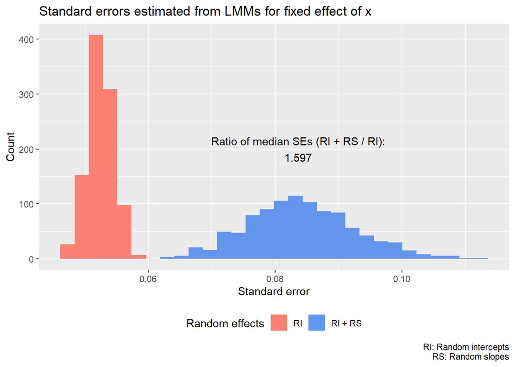

```r
p
```

Barr et al. advise “includ[ing] the maximal random effects structure *justified by the design*.” Practical advice relevant to this case comes from Gelman, who has pointed out that omitting terms (e.g., a random effect, an interaction of fixed effects) is still taking a position on them: It’s fixing them to zero. Our task is to determine if that is actually reasonable.

[Schielzeth and Forstmeier (2009)](https://academic.oup.com/beheco/article/20/2/416/218997) described this problem and made a helpful distinction between models targeting predictors that vary between-cluster versus models targeting predictors that vary within-cluster:

> …in a study of differential allocation, [female zebra finches] are paired experimentally to either attractive or unattractive [male zebra finches [(Bolund et al., 2009)](https://royalsocietypublishing.org/doi/10.1098/rspb.2008.1251)]. They are allowed to produce a clutch, and egg sizes are measured for all eggs. When the interest is to estimate the effect of the treatment (attractive vs. unattractive male) on mean egg size, it is sufficient to include individual-specific random intercept effects, that is, allowing females to differ in their mean egg sizes and hence intercepts. This will effectively control for the nonindependence of eggs coming from the same female when the factor of interest, the treatment, is applied to some of the females. However, many studies also focused on how the treatment affects the patterns of female investment over the laying sequence within a clutch. In this case, a model that controls for individual-specific intercepts only, but not for individual-specific slopes of investment (of egg size over the laying sequence), will greatly underestimate the *P* value of 1) the slope main effect and 2) the treatment by laying order interaction, leading to many false-positive findings.